# DiNeR Tutorial

DiNeR (*Di*fferential *Ne*twork Visualization in *R*) is a library built on top of `ggplot` meant to visualize comparisons among groups of networks.

```r
source("./DifferentialNetworkVis.R")
library(tidyverse)
```

## Create dummy data

TODO: maybe use some random Giotto output later

```r
test_df_1 <- data.frame(N1 = c("A","B","C"), N2 = c("A","A","F"), Weight=c(2.78, -5.12, -1.28), Type=c("Enriched", "Depleted", "Depleted"), stringsAsFactors=FALSE)
test_df_2 <- data.frame(N1 = c("E","A","A","H","C","F"), N2 = c("D","B","F","G","A","F"), Weight=c(2.78, -5.12, 1.28, 6.7, 1.9, -8.3), Type=c("Enriched", "Depleted", "Enriched", "Enriched", "Enriched", "Depleted"), stringsAsFactors=FALSE)
test_df_3 <- data.frame(N1 = c("A","B","F","C"), N2 = c("G","A","B","D"), Weight=c(1,2,3,4), Type=c("Enriched", "Enriched", "Enriched", "Enriched"), stringsAsFactors=FALSE)
```

## Creating object

Our basic DiNeR object requires a list of `data.frame` objects. Each `data.frame` corresponds to node adjacency within an individual’s network.

```r
edge_lists <- lapply(list(test_df_1, test_df_2, test_df_3), function(x){
  return(x[,c("N1", "N2")])
})

print(edge_lists)
```

```
## [[1]]
##   N1 N2
## 1  A  A
## 2  B  A
## 3  C  F
##
## [[2]]
##   N1 N2
## 1  E  D
## 2  A  B
## 3  A  F
## 4  H  G
## 5  C  A
## 6  F  F
##
## [[3]]
##   N1 N2
## 1  A  G
## 2  B  A
## 3  F  B
## 4  C  D
```

```r
diff_network_object <- create_diff_network_object(edge_lists)

print(diff_network_object)
```

```
## $EdgeList
## $EdgeList[[1]]
##   N1 N2
## 1  A  A
## 2  B  A
## 3  C  F
##
## $EdgeList[[2]]
##   N1 N2
## 1  E  D
## 2  A  B
## 3  A  F
## 4  H  G
## 5  C  A
## 6  F  F
##
## $EdgeList[[3]]
##   N1 N2
## 1  A  G
## 2  B  A
## 3  F  B
## 4  C  D
##
##
## $NodeXY
##   Node  X  Y radius
## 1    A 10 10      1
## 2    B 20 10      1
## 3    C 30 10      1
## 4    E 15 20      1
## 5    H 25 20      1
## 6    F 35 20      1
## 7    D 10 30      1
## 8    G 20 30      1
```

Creating the object just sets up the basic topology for each individual. However, we can also add information about: - Individuals (patient identifiers, diagnosis, age) - Nodes and Edges (labels, weights, classes)

Adding information for each individual is done using the `add_individual_features` function.

```r
individual_info <- data.frame(Index=c(1,2,3), PatientID=c("Patient 131", "Patient 32", "Patient 203"), Diagnosis=c("Control", "Disease", "Disease"))
diff_network_object = add_individual_features(diff_network_object, individual_info)
```

```r
diff_network_object = add_individual_features(diff_network_object, data.frame(Age=c(47, 53, 28)))
```

```r
diff_network_object
```

```
## $EdgeList
## $EdgeList[[1]]
##   N1 N2
## 1  A  A
## 2  B  A
## 3  C  F
##
## $EdgeList[[2]]
##   N1 N2
## 1  E  D
## 2  A  B
## 3  A  F
## 4  H  G
## 5  C  A
## 6  F  F
##
## $EdgeList[[3]]
##   N1 N2
## 1  A  G
## 2  B  A
## 3  F  B
## 4  C  D
##
##
## $NodeXY
##   Node  X  Y radius
## 1    A 10 10      1
## 2    B 20 10      1
## 3    C 30 10      1
## 4    E 15 20      1
## 5    H 25 20      1
## 6    F 35 20      1
## 7    D 10 30      1
## 8    G 20 30      1
##
## $IndividualFeatures
##   Index   PatientID Diagnosis Age
## 1     1 Patient 131   Control  47
## 2     2  Patient 32   Disease  53
## 3     3 Patient 203   Disease  28
```

We can add edge features using `add_edge_features`.

```r
edge_feature_list = edge_lists <- lapply(list(test_df_1, test_df_2, test_df_3), function(x){
  return(x[,c("Weight", "Type")])
})

diff_network_object = add_edge_features(diff_network_object, edge_feature_list)

diff_network_object
```

```
## $EdgeList
## $EdgeList[[1]]
##   N1 N2
## 1  A  A
## 2  B  A
## 3  C  F
##
## $EdgeList[[2]]
##   N1 N2
## 1  E  D
## 2  A  B
## 3  A  F
## 4  H  G
## 5  C  A
## 6  F  F
##
## $EdgeList[[3]]
##   N1 N2
## 1  A  G
## 2  B  A
## 3  F  B
## 4  C  D
##
##
## $NodeXY
##   Node  X  Y radius
## 1    A 10 10      1
## 2    B 20 10      1
## 3    C 30 10      1
## 4    E 15 20      1
## 5    H 25 20      1
## 6    F 35 20      1
## 7    D 10 30      1
## 8    G 20 30      1
##
## $IndividualFeatures
##   Index   PatientID Diagnosis Age
## 1     1 Patient 131   Control  47
## 2     2  Patient 32   Disease  53
## 3     3 Patient 203   Disease  28
```

[output cut: 8 more lines]

```
## $EdgeFeatures[[2]]
##   Weight     Type
## 1   2.78 Enriched
## 2  -5.12 Depleted
## 3   1.28 Enriched
## 4   6.70 Enriched
## 5   1.90 Enriched
## 6  -8.30 Depleted
##
## $EdgeFeatures[[3]]
##   Weight     Type
## 1      1 Enriched
## 2      2 Enriched
## 3      3 Enriched
## 4      4 Enriched
```

## Individual Network Visualization

Using `plot individual` with no other inputs.

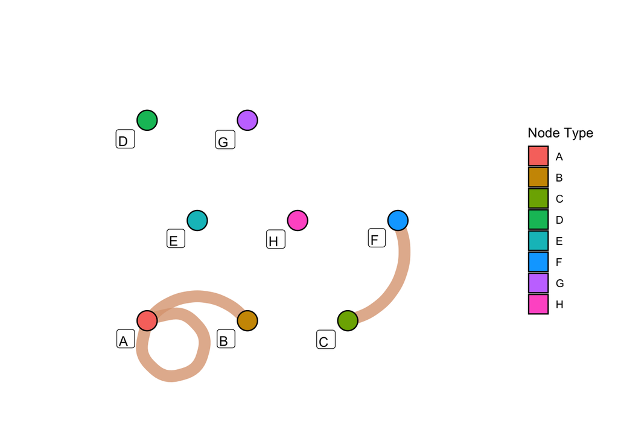

```r
plot_individual(diff_network_object)
```

The color scheme using the above code will be randomly decided. We can, however, add our own color scheme.

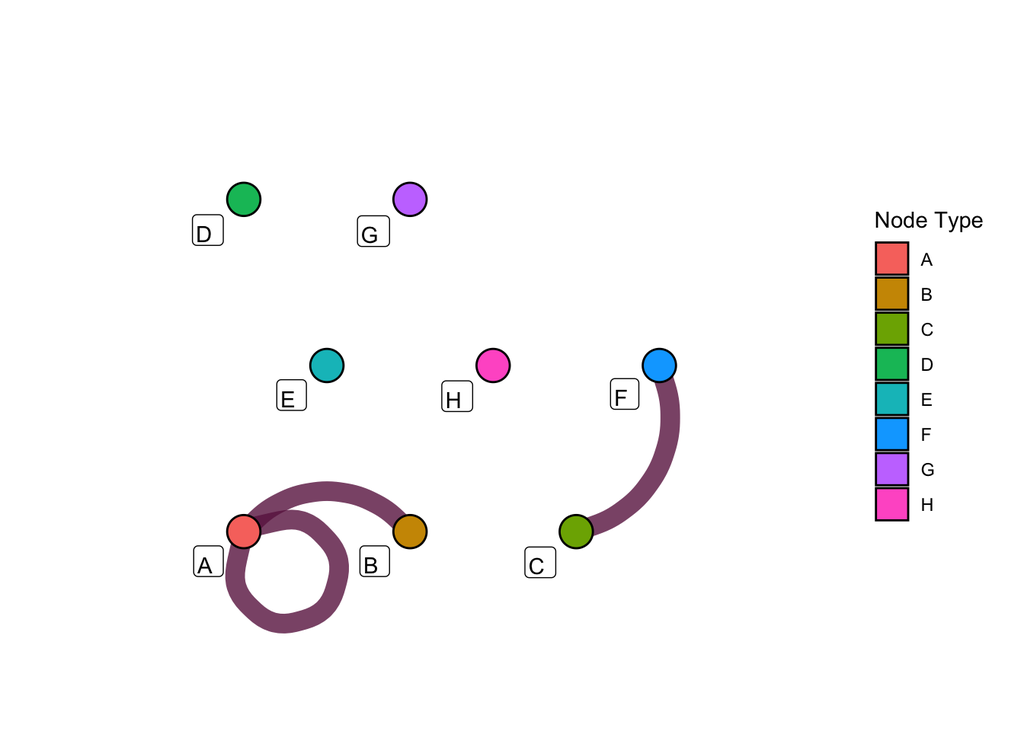

```r
#TODO: need to add input for node colors?
colors <- data.frame(high=c("#191970", "#ADD8E6", "#7FFFD4"), low=c("#9A2A2A", "#FAA0A0", "#2AAA8A"))
plot_individual(diff_network_object, colors=colors)
```

We can also use `lapply` to run this on all of our data using the `idx` parameter.

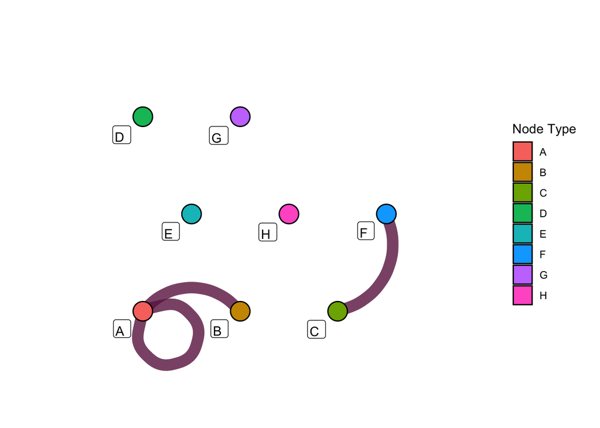

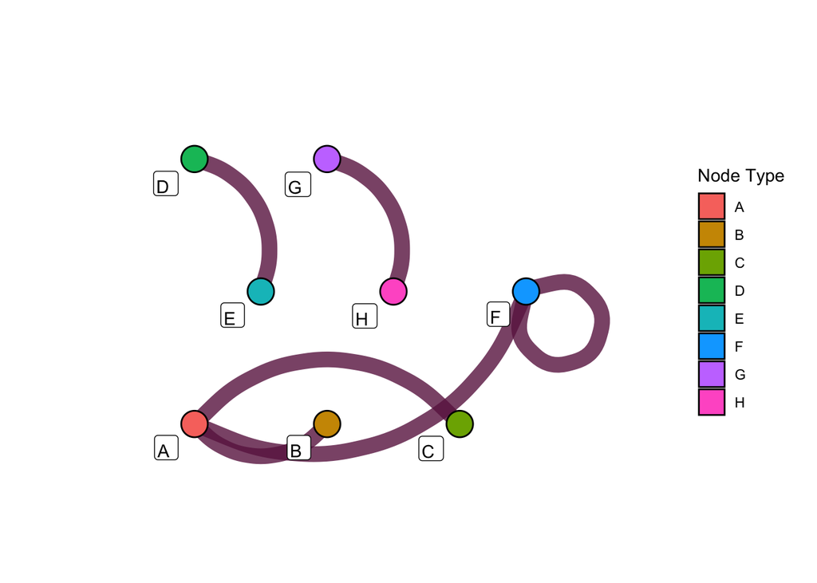

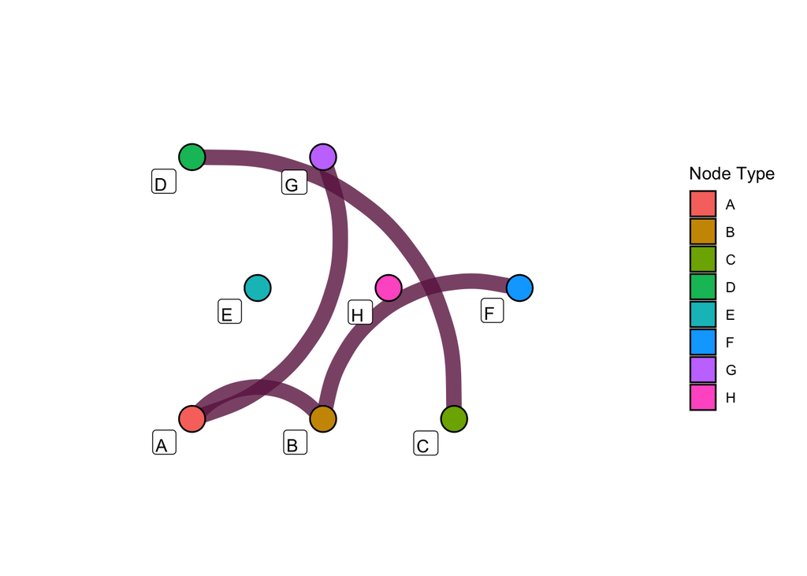

```r
# TODO: the colors for edges aren't the same for all patients... need to use rownames
lapply(1:3, function(i){
  plot_individual(diff_network_object, idx=i, colors=colors)
})
```

## More comparisons across individuals

Consensus edge plots allow us to see the occurrence of edges

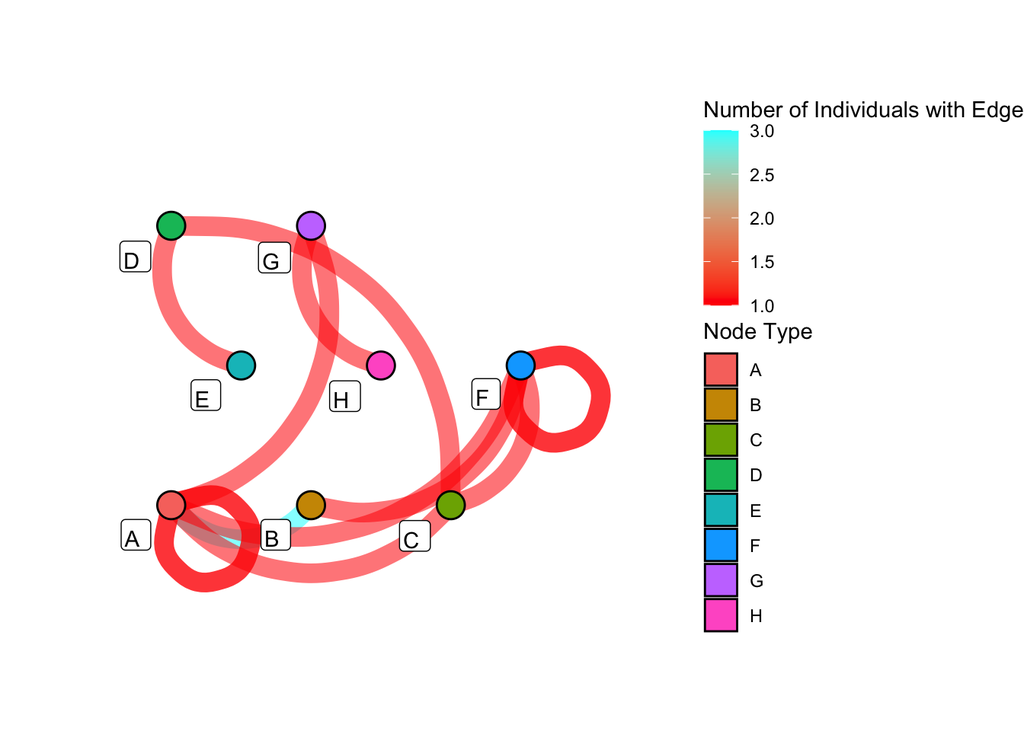

```r
# TODO: make edge legend gradient or remove 1.5, 2.5 etc.
# TODO: need to change legend labels for all (use labels)
consensus_edge(diff_network_object)
```

## Pie charts

Pie charts for one group

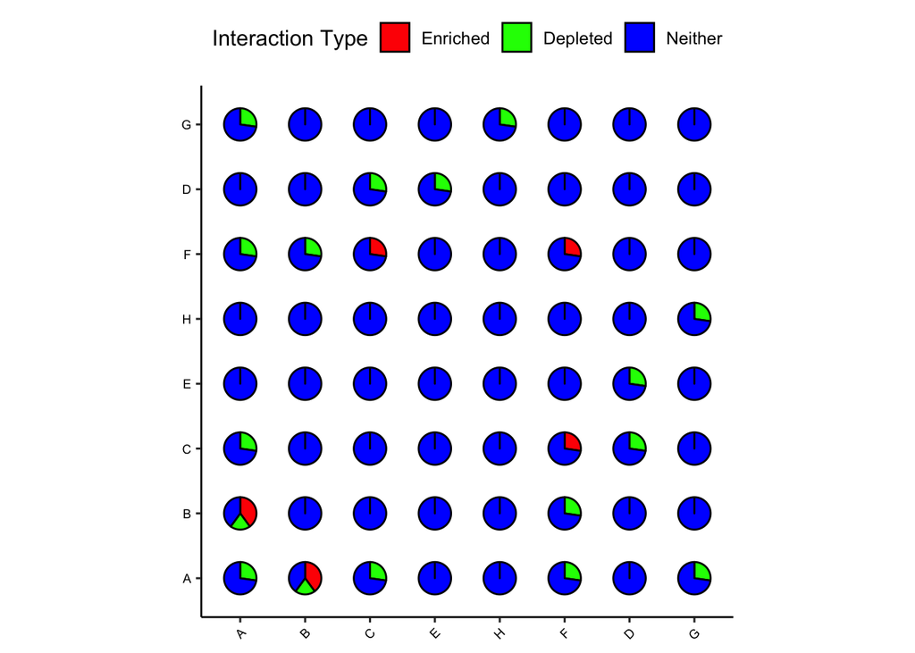

```r
make_piecharts(diff_network_object, edge_feature="Type")
```

```r
#TODO: change color schemes

#TODO: change label order
```

We can also create an additional visualization for multiple groups

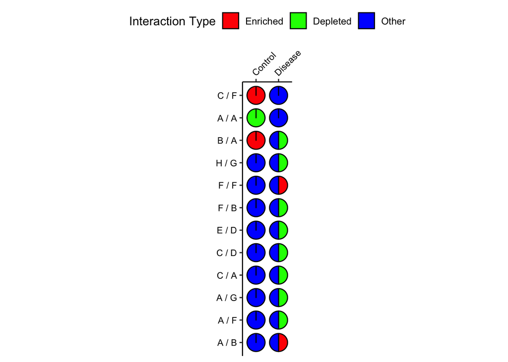

```r
make_piecharts_by_group(diff_network_object, edge_feature="Type", group_label="Diagnosis")
```

## Working with igraph functionality

Because we are working with networks, we can leverage some of the functionality of the `igraph` package to calculate metrics. The `add_graphs` function creates an additional item in our DiNeR object, a list of `igraph` representations of our graph. The `add_graphs` function includes a parameter called `edge_weight` that will create a weighted graph with the desired weight if included.

```r
diff_network_object = add_graphs(diff_network_object, edge_weight="Weight")

print(diff_network_object)
```

```
## $EdgeList
## $EdgeList[[1]]
##   N1 N2
## 1  A  A
## 2  B  A
## 3  C  F
##
## $EdgeList[[2]]
##   N1 N2
## 1  E  D
## 2  A  B
## 3  A  F
## 4  H  G
## 5  C  A
## 6  F  F
##
## $EdgeList[[3]]
##   N1 N2
## 1  A  G
## 2  B  A
## 3  F  B
## 4  C  D
##
##
## $NodeXY
##   Node  X  Y radius
## 1    A 10 10      1
## 2    B 20 10      1
## 3    C 30 10      1
## 4    E 15 20      1
## 5    H 25 20      1
## 6    F 35 20      1
## 7    D 10 30      1
## 8    G 20 30      1
##
## $IndividualFeatures
##   Index   PatientID Diagnosis Age
## 1     1 Patient 131   Control  47
## 2     2  Patient 32   Disease  53
## 3     3 Patient 203   Disease  28
```

[output cut: 28 more lines]

```
## + attr: name (v/c), weight (e/n)
## + edges from bbfbf48 (vertex names):
## [1] A--A A--B C--F
##
## $Graphs[[2]]
## IGRAPH f9d90b4 UNW- 8 6 --
## + attr: name (v/c), weight (e/n)
## + edges from f9d90b4 (vertex names):
## [1] E--D A--B A--F H--G A--C F--F
##
## $Graphs[[3]]
## IGRAPH 9e1bf39 UNW- 6 4 --
## + attr: name (v/c), weight (e/n)
## + edges from 9e1bf39 (vertex names):
## [1] A--G A--B B--F C--D
```

```r
# TODO: show workflow for coloring nodes in individual networks based on hub score

lapply(diff_network_object$graphs, hub_score)
```

```
## list()
```

## Making edits to network visualizations

```r
#TODO: how can we change some of the elements, i.e. legend fonts, sizes, etc?
```

## My own to-do list

```r
#TODO: include a way to label all "empty" edges. i.e. if it isn't enriched or depleted, it's neither
```